# HW5 - Make Data Move

Jonathan Rystrøm

28 september, 2021

# Explore the recent global developments with R

Today, you will load a filtered gapminder dataset - with a subset of data on global development from 1952 - 2007 in increments of 5 years - to capture the period between the Second World War and the Global Financial Crisis.

**Your task: Explore the data and visualise it in both static and animated ways, providing answers and solutions to 7 questions/tasks below.**

## Get the necessary packages

First, start with installing the relevant packages ‘tidyverse’, ‘gganimate’, and ‘gapminder’.

## Look at the data

First, see which specific years are actually represented in the dataset and what variables are being recorded for each country. Note that when you run the cell below, Rmarkdown will give you two results - one for each line - that you can flip between.

```r
unique(gapminder$year)
```

```
##  [1] 1952 1957 1962 1967 1972 1977 1982 1987 1992 1997 2002 2007
```

```r
head(gapminder)
```

```
## # A tibble: 6 x 6
##   country     continent  year lifeExp      pop gdpPercap
##   <fct>       <fct>     <int>   <dbl>    <int>     <dbl>
## 1 Afghanistan Asia       1952    28.8  8425333      779.
## 2 Afghanistan Asia       1957    30.3  9240934      821.
## 3 Afghanistan Asia       1962    32.0 10267083      853.
## 4 Afghanistan Asia       1967    34.0 11537966      836.
## 5 Afghanistan Asia       1972    36.1 13079460      740.
## 6 Afghanistan Asia       1977    38.4 14880372      786.
```

The dataset contains information on each country in the sampled year, its continent, life expectancy, population, and GDP per capita.

Let’s plot all the countries in 1952.

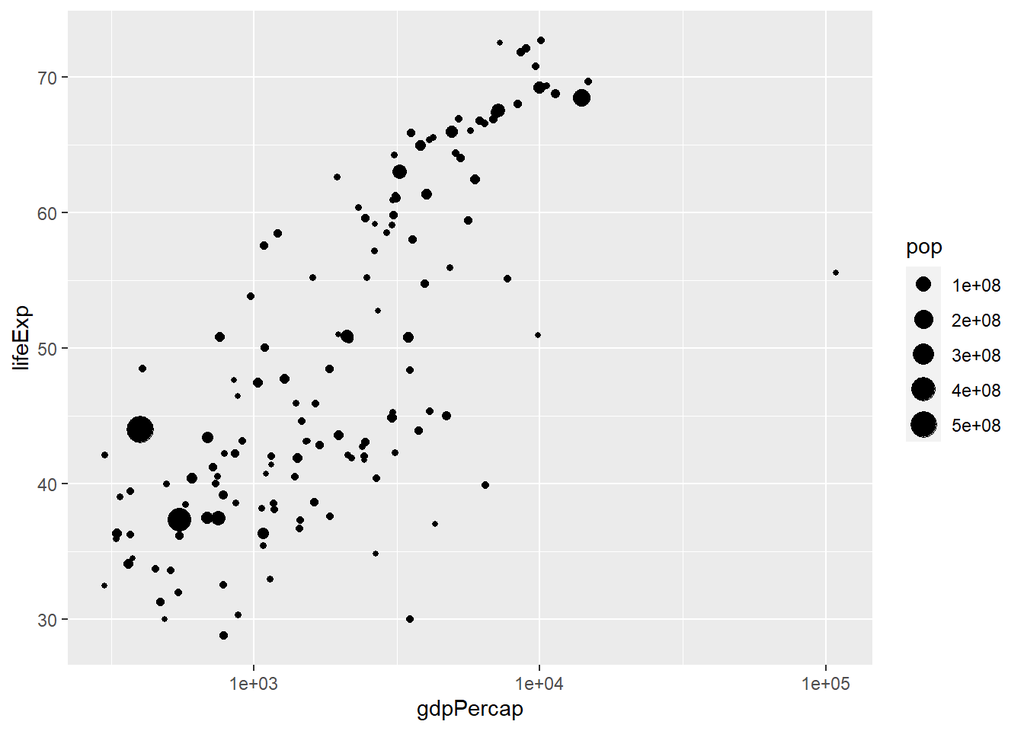

```r
ggplot(subset(gapminder, year == 1952), aes(gdpPercap, lifeExp, size = pop)) +
  geom_point() +
  scale_x_log10()
```

We see an interesting spread with an outlier to the right. Answer the following questions, please:

Q1. Why does it make sense to have a log10 scale on x axis? A1. Because there’s orders of magnitude difference between the different countries

Q2. What country is the richest in 1952 (far right on x axis)?

```r
gapminder %>%
  filter(year == 1952) %>%
  filter(gdpPercap == max(gdpPercap)) %>%
  select(country, gdpPercap)
```

```
## # A tibble: 1 x 2
##   country gdpPercap
##   <fct>       <dbl>
## 1 Kuwait    108382.
```

Here we see that the most wealthy country per capita in 1952 was **Kuwait**

You can generate a similar plot for 2007 and compare the differences

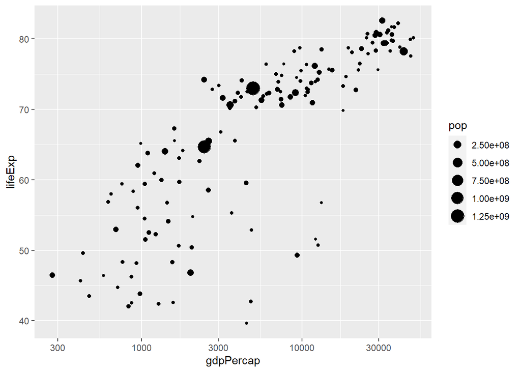

```r
ggplot(subset(gapminder, year == 2007), aes(gdpPercap, lifeExp, size = pop)) +
  geom_point() +
  scale_x_log10()
```

The black bubbles are a bit hard to read, the comparison would be easier with a bit more visual differentiation.

Q3. Can you differentiate the continents by color and fix the axis labels?

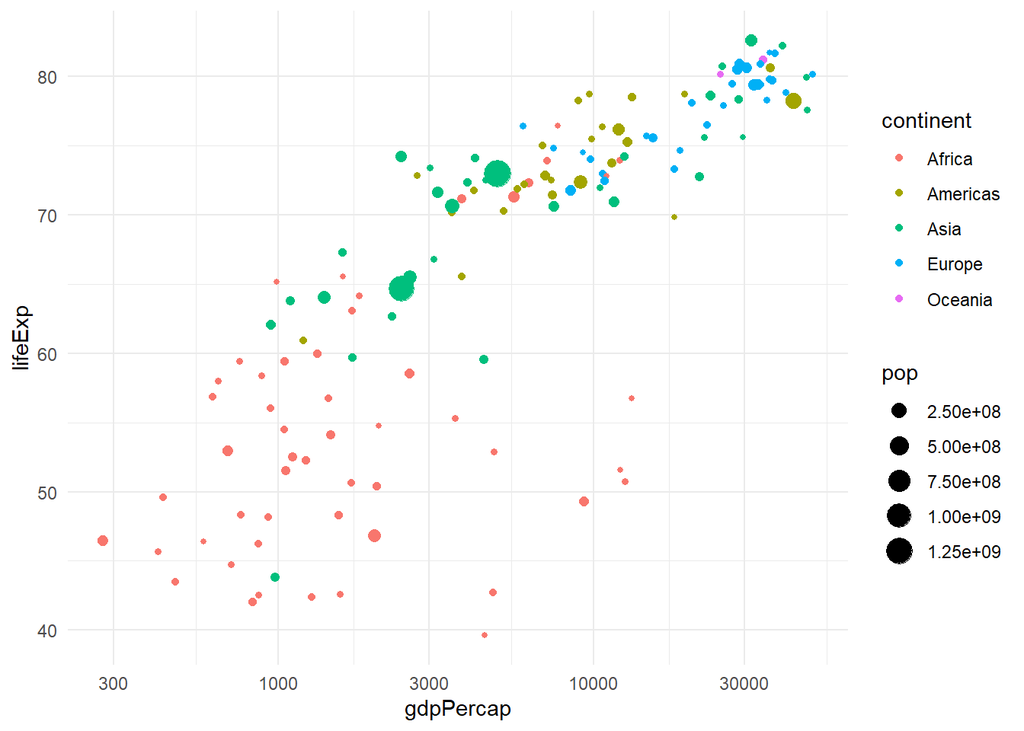

```r
ggplot(subset(gapminder, year == 2007), aes(gdpPercap, lifeExp, size = pop, colour = continent)) +
  geom_point() +
  scale_x_log10() +
  theme_minimal()
```

Q4. What are the five richest countries in the world in 2007?

```r
gapminder %>%
  filter(year == 2007) %>%
  arrange(desc(gdpPercap)) %>%
  top_n(5) %>%
  select(country, gdpPercap)
```

```
## # A tibble: 5 x 2
##   country       gdpPercap
##   <fct>             <dbl>
## 1 Norway           49357.
## 2 Kuwait           47307.
## 3 Singapore        47143.
## 4 United States    42952.
## 5 Ireland          40676.
```

The five richest countries are *Norway*, *Kuwait*, *Singapore*, *United States* and *Ireland*

## Make it move!

The comparison would be easier if we had the two graphs together, animated. We have a lovely tool in R to do this: the `gganimate` package. And there are two ways of animating the gapminder ggplot.

### Option 1: Animate using transition_states()

The first step is to create the object-to-be-animated

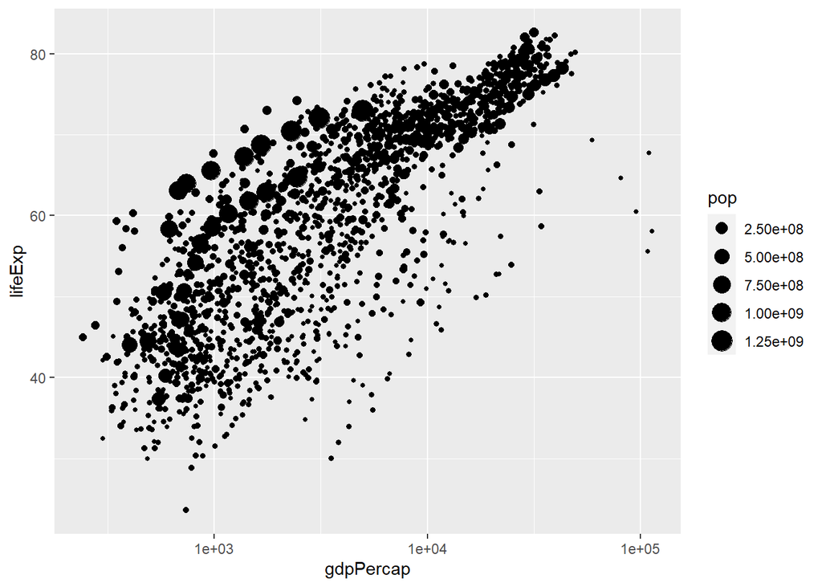

```r
anim <- ggplot(gapminder, aes(gdpPercap, lifeExp, size = pop)) +
  geom_point() +
  scale_x_log10()  # convert x to log scale
anim
```

This plot collates all the points across time. The next step is to split it into years and animate it. This may take some time, depending on the processing power of your computer (and other things you are asking it to do). Beware that the animation might appear in the ‘Viewer’ pane, not in this rmd preview. You need to knit the document to get the viz inside an html file.

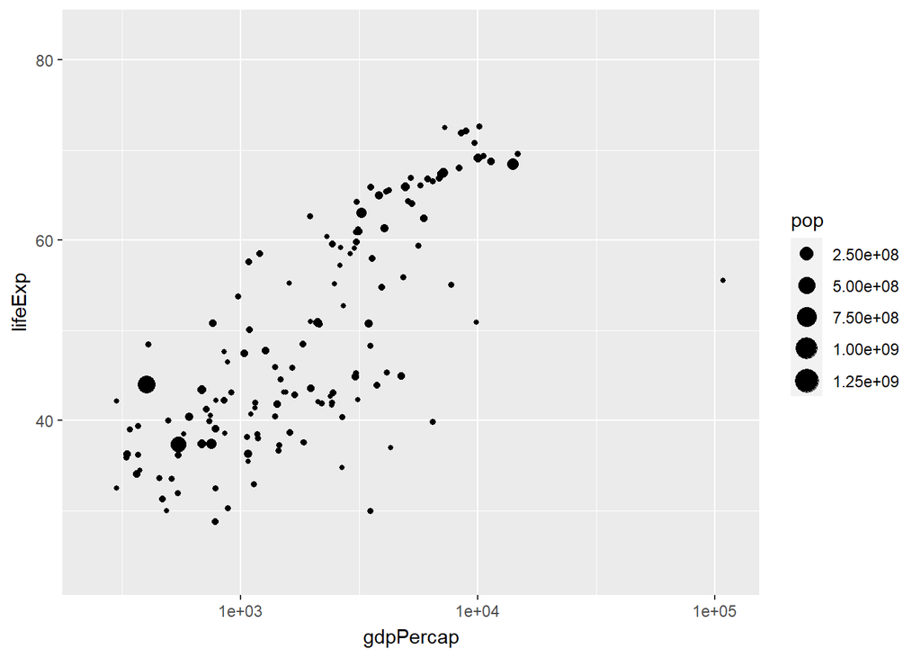

```r
anim_plot <- anim + transition_states(year,
                      transition_length = 1,
                      state_length = 1)
anim_plot
```

Notice how the animation moves jerkily, ‘jumping’ from one year to the next 12 times in total. This is a bit clunky, which is why it’s good we have another option.

### Option 2 Animate using transition_time()

This option smoothes the transition between different ‘frames’, because it interpolates and adds transitional years where there are gaps in the timeseries data.

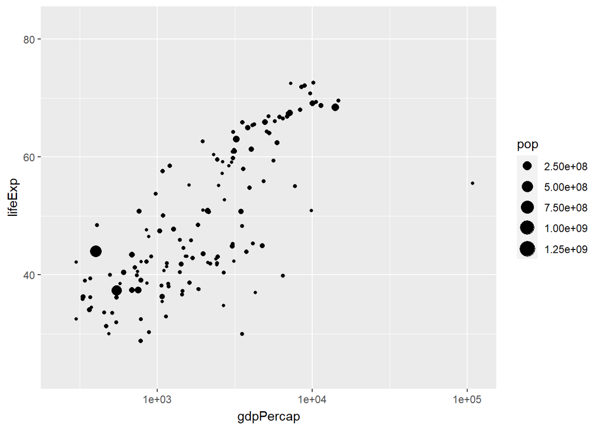

```r
anim2 <- ggplot(gapminder, aes(gdpPercap, lifeExp, size = pop)) +
  geom_point() +
  scale_x_log10() + # convert x to log scale
  transition_time(year)
anim2
```

The much smoother movement in Option 2 will be much more noticeable if you add a title to the chart, that will page through the years corresponding to each frame.

Q5 Can you add a title to one or both of the animations above that will change in sync with the animation? [hint: search labeling for transition_states() and transition_time() functions respectively]

Let’s try with transition_time() (anim_2)

```r
anim3 <- anim2 +
  ggtitle("Devlopment over time in gdp and life expectancy",
          subtitle = "Year {frame_time}")
```

Q6 Can you made the axes’ labels and units more readable? Consider expanding the abreviated lables as well as the scientific notation in the legend and x axis to whole numbers.[hint:search disabling scientific notation]

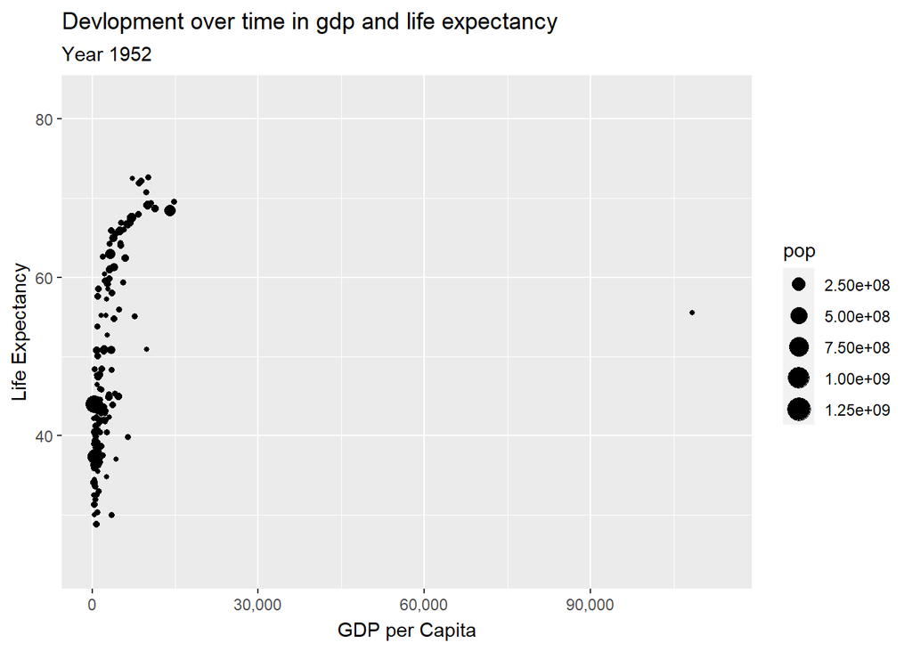

```r
require(scales)
anim3 +
  labs(x = "GDP per Capita", y = "Life Expectancy") +
  scale_x_continuous(labels = comma)
```

I have followed the answer proposed [here](https://stackoverflow.com/a/14564102)

Q7 Come up with a question you want to answer using the gapminder data and write it down. Then, create a data visualisation that answers the question and explain how your visualization answers the question. (Example: you wish to see what was mean life expectancy across the continents in the year you were born versus your parents’ birth years). [hint: if you wish to have more data than is in the filtered gapminder, you can load either the `gapminder_unfiltered` dataset and download more at https://www.gapminder.org/data/ ]

I want to figure out which Nordic country has had the biggest improvement in health since the 1950’ies

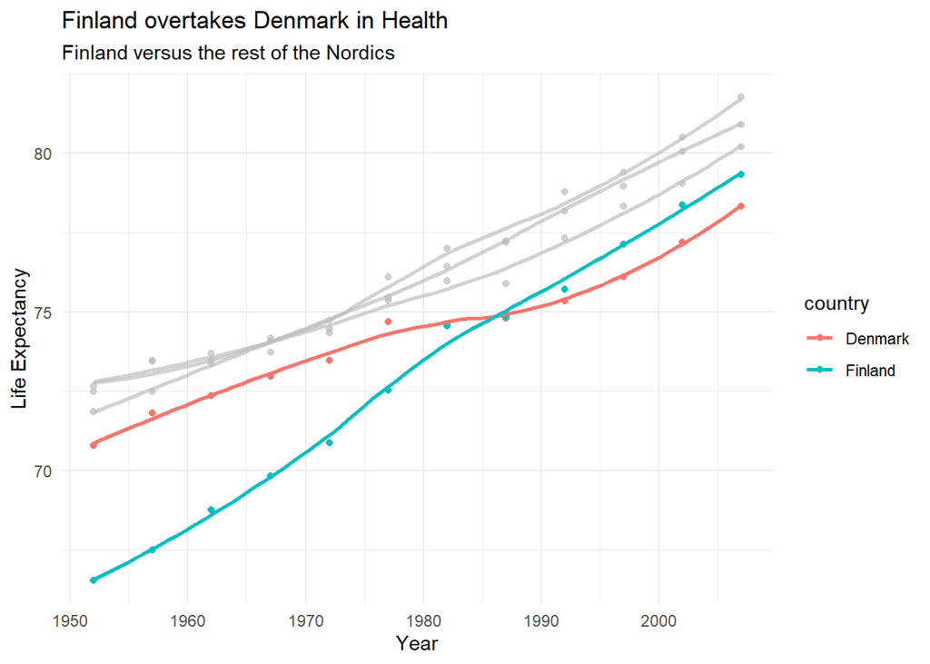

```r
gapminder %>%
  filter(country %in% c("Denmark", "Norway", "Sweden", "Finland", "Iceland")) %>%
  select(country, year, lifeExp) %>%
  mutate(country = as_factor(country)) %>%
  ggplot(aes(x = year, y = lifeExp, colour = country)) +
  geom_point() +
  geom_smooth(se=F) +
  theme_minimal() +
  labs(
    title = "Finland overtakes Denmark in Health",
    subtitle = "Finland versus the rest of the Nordics",
    x = "Year",
    y = "Life Expectancy"
    ) +
  gghighlight(country %in% c("Finland", "Denmark"), use_direct_label = FALSE)
```